# Analisis Prediktif Harga Rumah Menggunakan Tree Based Algorithm

Moh. Rosidi 7/22/2020

# Dataset Ames

- https://ww2.amstat.org/publications/jse/v19n3/decock/DataDocumentation.txt
- http://ww2.amstat.org/publications/jse/v19n3/decock.pdf

# Persiapan

## Library

Terdapat beberapa paket yang digunakan dalam pembuatan model prediktif menggunakan *tree based algorithm*. Paket-paket ditampilkan sebagai berikut:

```r
# library pembantu
library(plyr)
library(e1071)
library(foreach)
library(import)
library(tidyverse)
library(rsample)
library(recipes)
library(DataExplorer)
library(skimr)
library(modeldata)

# library model
library(caret)
library(rpart)
library(ipred)
library(randomForest)
library(gbm)

# paket penjelasan model
library(rpart.plot)
library(vip)
library(pdp)
```

**Paket Pembantu**

1. `plyr` : paket manipulasi data yang digunakan untuk membantu proses *fitting* sejumlah model pohon.
2. `e1071` : paket dengan sejumlah fungsi untuk melakukan *latent class analysis, short time Fourier transform, fuzzy clustering, support vector machines, shortest path computation, bagged clustering, naive Bayes classifier*, dll. Paket ini merupakan paket pembantu dalam proses *fitting* sejumlah model pohon
3. `foreach` : paket untuk melakukan *parallel computing*. Diperlukan untuk melakukan *fitting* model *parallel random forest*
4. `import` : paket yang menangani *dependency* fungsi antar paket dalam proses *fitting* model *parallel random forest*
5. `tidyverse` : kumpulan paket dalam bidang data science
6. `rsample` : membantu proses *data splitting*
7. `recipes`: membantu proses data pra-pemrosesan
8. `DataExplorer` : EDA
9. `skimr` : membuat ringkasan data
10. `modeldata` : kumpulan dataset untuk membuat model *machine learning*

**Paket untuk Membangun Model**

1. `caret` : berisikan sejumlah fungsi yang dapat merampingkan proses pembuatan model regresi dan klasifikasi
2. `rpart` : membentuk model *decision trees*
3. `ipred` : membentuk model *bagging*
4. `randomForest` : membentuk model *random forest*
5. `gbm` : membentuk model *gradient boost model*

**Paket Interpretasi Model**

1. `rpart.plot` : visualisasi *decision trees*
2. `vip` : visualisasi *variable importance*
3. `pdp` : visualisasi plot ketergantungan parsial

## Import Dataset

Import dataset dilakukan dengan menggunakan fungsi `data()`. Fungsi ini digunakan untuk mengambil data yang ada dalam sebuah paket.

```r
data("ames")
```

# Data Splitting

Proses *data splitting* dilakukan setelah data di import ke dalam sistem. Hal ini dilakukan untuk memastikan tidak adanya kebocoran data yang mempengaruhi proses pembuatan model. Data dipisah menjadi dua buah set, yaitu: *training* dan *test*. Data *training* adalah data yang akan kita gunakan untuk membentuk model. Seluruh proses sebelum uji model akan menggunakan data *training*. Proses tersebut, antara lain: EDA, *feature engineering*, dan validasi silang. Data *test* hanya digunakan saat kita akan menguji performa model dengan data baru yang belum pernah dilihat sebelumnya.

Terdapat dua buah jenis sampling pada tahapan *data splitting*, yaitu:

1. *random sampling* : sampling acak tanpa mempertimbangkan adanya strata dalam data
2. *startified random sampling* : sampling dengan memperhatikan strata dalam sebuah variabel.

Dalam proses pembentukan model kali ini, kita akan menggunakan metode kedua dengan tujuan untuk memperoleh distribusi yang seragam dari variabel target (`Sale_Price`).

```r
set.seed(123)

split  <- initial_split(ames, prop = 0.7, strata = "Sale_Price")
ames_train  <- training(split)
ames_test   <- testing(split)
```

Untuk mengecek distribusi dari kedua set data, kita dapat mevisualisasikan distribusi dari variabel target pada kedua set tersebut.

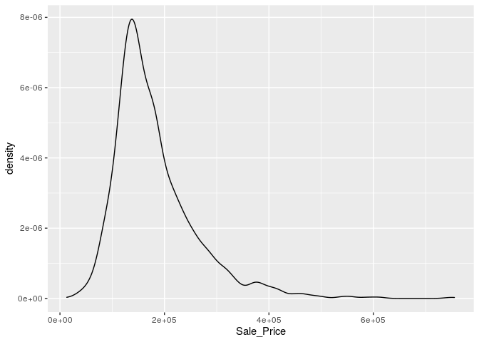

```r
# training set
ggplot(ames_train, aes(x = Sale_Price)) +
  geom_density()
```

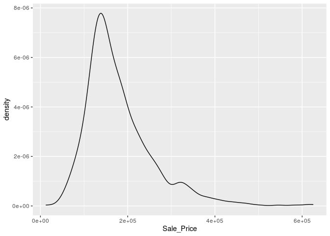

```r
# test set
ggplot(ames_test, aes(x = Sale_Price)) +
  geom_density()
```

# Analisis Data Eksploratif

Analsiis data eksploratif (EDA) ditujukan untuk mengenali data sebelum kita menentukan algoritma yang cocok digunakan untuk menganalisa data lebih lanjut. EDA merupakan sebuah proses iteratif yang secara garis besar menjawab beberapa pertanyaan umum, seperti:

1. Bagaimana distribusi data pada masing-masing variabel?
2. Apakah terdapat asosiasi atau hubungan antar variabel dalam data?

## Ringkasan Data

1. `glimpse()`: varian dari `str()` untuk mengecek struktur data. Fungsi ini menampilkan transpose dari tabel data dengan menambahkan informasi, seperti: jenis data dan dimensi tabel.
2. `skim()` : fungsi dari paket `skimr` untuk membuat ringkasan data yang lebih detail dibanding `glimpse()`, seperti: statistika deskriptif masing-masing kolom, dan informasi *missing value* dari masing-masing kolom.
3. `plot_missing()` : fungsi untuk memvisualisasikan persentase *missing value* pada masing-masing variabel atau kolom data

```r
glimpse(ames_train)
```

```
## Rows: 2,053
## Columns: 74
## $ MS_SubClass        <fct> One_Story_1946_and_Newer_All_Styles, One_Story_194…
## $ MS_Zoning          <fct> Residential_Low_Density, Residential_High_Density,…
## $ Lot_Frontage       <dbl> 141, 80, 81, 78, 41, 39, 60, 75, 63, 85, 47, 152, …
## $ Lot_Area           <int> 31770, 11622, 14267, 9978, 4920, 5389, 7500, 10000…
## $ Street             <fct> Pave, Pave, Pave, Pave, Pave, Pave, Pave, Pave, Pa…
## $ Alley              <fct> No_Alley_Access, No_Alley_Access, No_Alley_Access,…
## $ Lot_Shape          <fct> Slightly_Irregular, Regular, Slightly_Irregular, S…
## $ Land_Contour       <fct> Lvl, Lvl, Lvl, Lvl, Lvl, Lvl, Lvl, Lvl, Lvl, Lvl, …
## $ Utilities          <fct> AllPub, AllPub, AllPub, AllPub, AllPub, AllPub, Al…
## $ Lot_Config         <fct> Corner, Inside, Corner, Inside, Inside, Inside, In…
## $ Land_Slope         <fct> Gtl, Gtl, Gtl, Gtl, Gtl, Gtl, Gtl, Gtl, Gtl, Gtl, …
## $ Neighborhood       <fct> North_Ames, North_Ames, North_Ames, Gilbert, Stone…
## $ Condition_1        <fct> Norm, Feedr, Norm, Norm, Norm, Norm, Norm, Norm, N…
```

[output cut: 61 more lines]

```r
skim(ames_train)
```

| Name | ames_train |
| --- | --- |
| Number of rows | 2053 |
| Number of columns | 74 |
| _______________________ |  |
| Column type frequency: |  |
| factor | 40 |
| numeric | 34 |
| ________________________ |  |
| Group variables | None |

Data summary

**Variable type: factor**

| skim_variable | n_missing | complete_rate | ordered | n_unique | top_counts |
| --- | --- | --- | --- | --- | --- |
| MS_SubClass | 0 | 1 | FALSE | 16 | One: 753, Two: 395, One: 211, One: 145 |
| MS_Zoning | 0 | 1 | FALSE | 7 | Res: 1571, Res: 338, Flo: 102, Res: 19 |
| Street | 0 | 1 | FALSE | 2 | Pav: 2046, Grv: 7 |
| Alley | 0 | 1 | FALSE | 3 | No_: 1909, Gra: 93, Pav: 51 |
| Lot_Shape | 0 | 1 | FALSE | 4 | Reg: 1321, Sli: 666, Mod: 54, Irr: 12 |
| Land_Contour | 0 | 1 | FALSE | 4 | Lvl: 1850, HLS: 83, Bnk: 75, Low: 45 |
| Utilities | 0 | 1 | FALSE | 3 | All: 2050, NoS: 2, NoS: 1 |
| Lot_Config | 0 | 1 | FALSE | 5 | Ins: 1494, Cor: 361, Cul: 127, FR2: 62 |
| Land_Slope | 0 | 1 | FALSE | 3 | Gtl: 1958, Mod: 86, Sev: 9 |
| Neighborhood | 0 | 1 | FALSE | 27 | Nor: 298, Col: 187, Old: 171, Edw: 146 |
| Condition_1 | 0 | 1 | FALSE | 9 | Nor: 1768, Fee: 120, Art: 63, RRA: 35 |
| Condition_2 | 0 | 1 | FALSE | 7 | Nor: 2031, Fee: 10, Pos: 4, Art: 3 |
| Bldg_Type | 0 | 1 | FALSE | 5 | One: 1692, Twn: 178, Twn: 74, Dup: 66 |
| House_Style | 0 | 1 | FALSE | 8 | One: 1030, Two: 614, One: 233, SLv: 84 |
| Overall_Cond | 0 | 1 | FALSE | 9 | Ave: 1168, Abo: 370, Goo: 280, Ver: 95 |
| Roof_Style | 0 | 1 | FALSE | 6 | Gab: 1627, Hip: 387, Gam: 17, Fla: 14 |
| Roof_Matl | 0 | 1 | FALSE | 5 | Com: 2024, Tar: 16, WdS: 7, WdS: 5 |
| Exterior_1st | 0 | 1 | FALSE | 14 | Vin: 718, Met: 321, Wd : 301, HdB: 295 |
| Exterior_2nd | 0 | 1 | FALSE | 16 | Vin: 710, Met: 321, Wd : 287, HdB: 267 |
| Mas_Vnr_Type | 0 | 1 | FALSE | 4 | Non: 1231, Brk: 624, Sto: 179, Brk: 19 |
| Exter_Cond | 0 | 1 | FALSE | 5 | Typ: 1792, Goo: 204, Fai: 43, Exc: 11 |
| Foundation | 0 | 1 | FALSE | 6 | PCo: 916, CBl: 870, Brk: 226, Sla: 30 |
| Bsmt_Cond | 0 | 1 | FALSE | 6 | Typ: 1834, Goo: 92, Fai: 71, No_: 52 |
| Bsmt_Exposure | 0 | 1 | FALSE | 5 | No: 1348, Av: 284, Gd: 205, Mn: 163 |
| BsmtFin_Type_1 | 0 | 1 | FALSE | 7 | GLQ: 599, Unf: 588, ALQ: 313, Rec: 207 |
| BsmtFin_Type_2 | 0 | 1 | FALSE | 7 | Unf: 1742, Rec: 81, LwQ: 66, No_: 53 |
| Heating | 0 | 1 | FALSE | 5 | Gas: 2021, Gas: 20, Gra: 7, Wal: 3 |
| Heating_QC | 0 | 1 | FALSE | 5 | Exc: 1052, Typ: 593, Goo: 340, Fai: 66 |
| Central_Air | 0 | 1 | FALSE | 2 | Y: 1916, N: 137 |
| Electrical | 0 | 1 | FALSE | 5 | SBr: 1873, Fus: 140, Fus: 32, Fus: 7 |
| Functional | 0 | 1 | FALSE | 7 | Typ: 1909, Min: 50, Min: 47, Mod: 25 |
| Garage_Type | 0 | 1 | FALSE | 7 | Att: 1230, Det: 534, Bui: 124, No_: 109 |
| Garage_Finish | 0 | 1 | FALSE | 4 | Unf: 863, RFn: 567, Fin: 512, No_: 111 |
| Garage_Cond | 0 | 1 | FALSE | 6 | Typ: 1870, No_: 111, Fai: 48, Goo: 12 |
| Paved_Drive | 0 | 1 | FALSE | 3 | Pav: 1862, Dir: 140, Par: 51 |
| Pool_QC | 0 | 1 | FALSE | 5 | No_: 2045, Exc: 3, Typ: 3, Fai: 1 |
| Fence | 0 | 1 | FALSE | 5 | No_: 1646, Min: 243, Goo: 80, Goo: 75 |
| Misc_Feature | 0 | 1 | FALSE | 4 | Non: 1982, She: 65, Gar: 4, Oth: 2 |
| Sale_Type | 0 | 1 | FALSE | 10 | WD : 1775, New: 159, COD: 65, Con: 22 |
| Sale_Condition | 0 | 1 | FALSE | 6 | Nor: 1692, Par: 164, Abn: 139, Fam: 36 |

**Variable type: numeric**

| skim_variable | n_missing | complete_rate | mean | sd | p0 | p25 | p50 | p75 | p100 | hist |
| --- | --- | --- | --- | --- | --- | --- | --- | --- | --- | --- |
| Lot_Frontage | 0 | 1 | 57.00 | 33.69 | 0.00 | 41.00 | 62.00 | 78.00 | 313.00 | ▇▇▁▁▁ |
| Lot_Area | 0 | 1 | 10121.14 | 8120.98 | 1300.00 | 7313.00 | 9375.00 | 11512.00 | 215245.00 | ▇▁▁▁▁ |
| Year_Built | 0 | 1 | 1971.07 | 30.52 | 1872.00 | 1952.00 | 1973.00 | 2000.00 | 2010.00 | ▁▂▃▆▇ |
| Year_Remod_Add | 0 | 1 | 1984.42 | 20.79 | 1950.00 | 1966.00 | 1993.00 | 2004.00 | 2010.00 | ▅▂▂▃▇ |
| Mas_Vnr_Area | 0 | 1 | 102.59 | 179.08 | 0.00 | 0.00 | 0.00 | 164.00 | 1600.00 | ▇▁▁▁▁ |
| BsmtFin_SF_1 | 0 | 1 | 4.16 | 2.24 | 1.00 | 3.00 | 3.00 | 7.00 | 7.00 | ▅▆▁▁▇ |
| BsmtFin_SF_2 | 0 | 1 | 52.20 | 172.62 | 0.00 | 0.00 | 0.00 | 0.00 | 1474.00 | ▇▁▁▁▁ |
| Bsmt_Unf_SF | 0 | 1 | 558.79 | 437.52 | 0.00 | 219.00 | 467.00 | 797.00 | 2336.00 | ▇▅▂▁▁ |
| Total_Bsmt_SF | 0 | 1 | 1050.67 | 425.77 | 0.00 | 784.00 | 992.00 | 1298.00 | 3206.00 | ▂▇▃▁▁ |
| First_Flr_SF | 0 | 1 | 1158.36 | 383.60 | 334.00 | 880.00 | 1083.00 | 1384.00 | 3820.00 | ▇▇▁▁▁ |
| Second_Flr_SF | 0 | 1 | 336.30 | 426.47 | 0.00 | 0.00 | 0.00 | 702.00 | 2065.00 | ▇▃▂▁▁ |
| Gr_Liv_Area | 0 | 1 | 1499.56 | 494.55 | 334.00 | 1136.00 | 1441.00 | 1743.00 | 4676.00 | ▅▇▂▁▁ |
| Bsmt_Full_Bath | 0 | 1 | 0.43 | 0.53 | 0.00 | 0.00 | 0.00 | 1.00 | 3.00 | ▇▆▁▁▁ |
| Bsmt_Half_Bath | 0 | 1 | 0.06 | 0.25 | 0.00 | 0.00 | 0.00 | 0.00 | 2.00 | ▇▁▁▁▁ |
| Full_Bath | 0 | 1 | 1.57 | 0.56 | 0.00 | 1.00 | 2.00 | 2.00 | 4.00 | ▁▇▇▁▁ |
| Half_Bath | 0 | 1 | 0.38 | 0.50 | 0.00 | 0.00 | 0.00 | 1.00 | 2.00 | ▇▁▅▁▁ |
| Bedroom_AbvGr | 0 | 1 | 2.84 | 0.83 | 0.00 | 2.00 | 3.00 | 3.00 | 8.00 | ▁▇▂▁▁ |
| Kitchen_AbvGr | 0 | 1 | 1.04 | 0.21 | 0.00 | 1.00 | 1.00 | 1.00 | 3.00 | ▁▇▁▁▁ |
| TotRms_AbvGrd | 0 | 1 | 6.42 | 1.54 | 2.00 | 5.00 | 6.00 | 7.00 | 14.00 | ▁▇▆▁▁ |
| Fireplaces | 0 | 1 | 0.61 | 0.65 | 0.00 | 0.00 | 1.00 | 1.00 | 3.00 | ▇▇▁▁▁ |
| Garage_Cars | 0 | 1 | 1.77 | 0.77 | 0.00 | 1.00 | 2.00 | 2.00 | 5.00 | ▅▇▂▁▁ |
| Garage_Area | 0 | 1 | 474.14 | 215.76 | 0.00 | 325.00 | 480.00 | 576.00 | 1390.00 | ▂▇▃▁▁ |
| Wood_Deck_SF | 0 | 1 | 92.98 | 123.01 | 0.00 | 0.00 | 0.00 | 168.00 | 857.00 | ▇▂▁▁▁ |
| Open_Porch_SF | 0 | 1 | 47.42 | 68.23 | 0.00 | 0.00 | 26.00 | 70.00 | 742.00 | ▇▁▁▁▁ |
| Enclosed_Porch | 0 | 1 | 24.02 | 65.83 | 0.00 | 0.00 | 0.00 | 0.00 | 1012.00 | ▇▁▁▁▁ |
| Three_season_porch | 0 | 1 | 2.99 | 27.75 | 0.00 | 0.00 | 0.00 | 0.00 | 508.00 | ▇▁▁▁▁ |
| Screen_Porch | 0 | 1 | 15.36 | 54.61 | 0.00 | 0.00 | 0.00 | 0.00 | 576.00 | ▇▁▁▁▁ |
| Pool_Area | 0 | 1 | 1.90 | 31.33 | 0.00 | 0.00 | 0.00 | 0.00 | 648.00 | ▇▁▁▁▁ |
| Misc_Val | 0 | 1 | 44.77 | 509.47 | 0.00 | 0.00 | 0.00 | 0.00 | 15500.00 | ▇▁▁▁▁ |
| Mo_Sold | 0 | 1 | 6.20 | 2.71 | 1.00 | 4.00 | 6.00 | 8.00 | 12.00 | ▅▆▇▃▃ |
| Year_Sold | 0 | 1 | 2007.79 | 1.31 | 2006.00 | 2007.00 | 2008.00 | 2009.00 | 2010.00 | ▇▇▇▇▃ |
| Sale_Price | 0 | 1 | 180996.28 | 80258.90 | 13100.00 | 129500.00 | 160000.00 | 213500.00 | 755000.00 | ▇▇▁▁▁ |
| Longitude | 0 | 1 | -93.64 | 0.03 | -93.69 | -93.66 | -93.64 | -93.62 | -93.58 | ▅▅▇▆▁ |
| Latitude | 0 | 1 | 42.03 | 0.02 | 41.99 | 42.02 | 42.03 | 42.05 | 42.06 | ▂▂▇▇▇ |

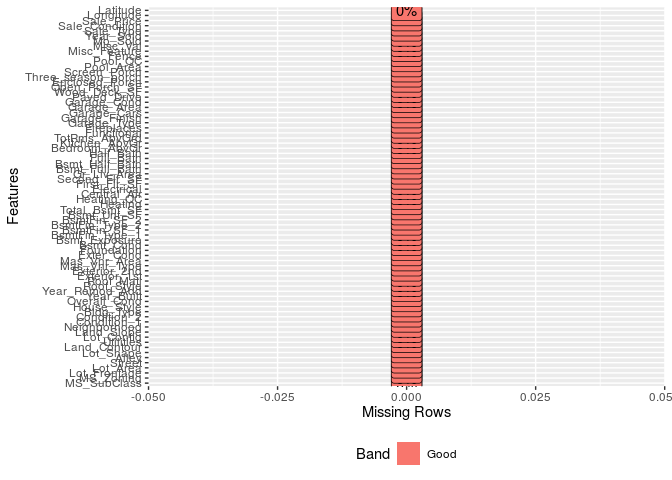

```r
plot_missing(ames_train)
```

Berdasarkan ringkasan data yang dihasilkan, diketahui dimensi data sebesar 2053 baris dan 74 kolom. Dengan rincian masing-masing kolom, yaitu: 40 kolom dengan jenis data factor dan 34 kolom dengan jenis data numeric. Informasi lain yang diketahui adalah seluruh kolom dalam data tidak memiliki *missing value*.

## Variasi

Variasi dari tiap variabel dapat divisualisasikan dengan menggunakan histogram (numerik) dan baplot (kategorikal).

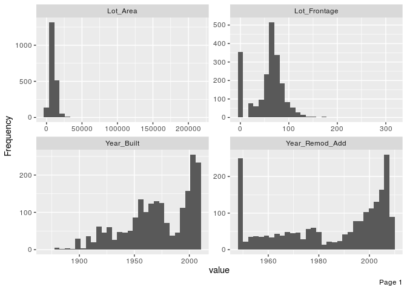

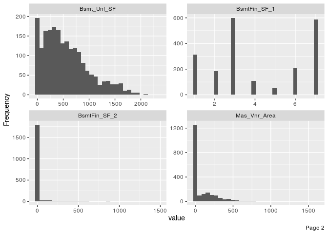

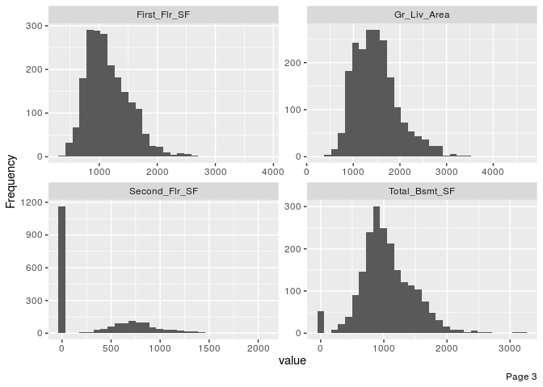

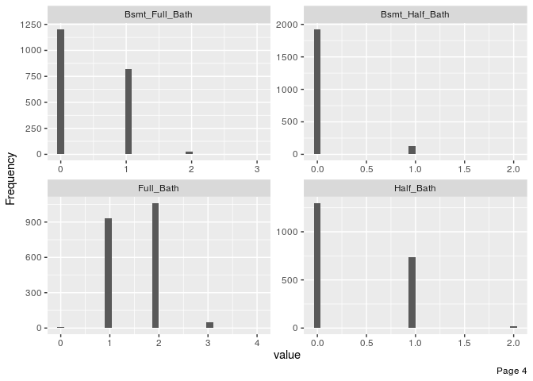

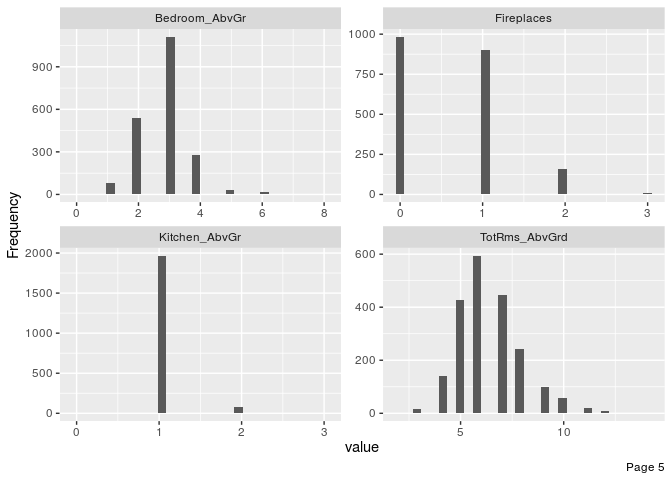

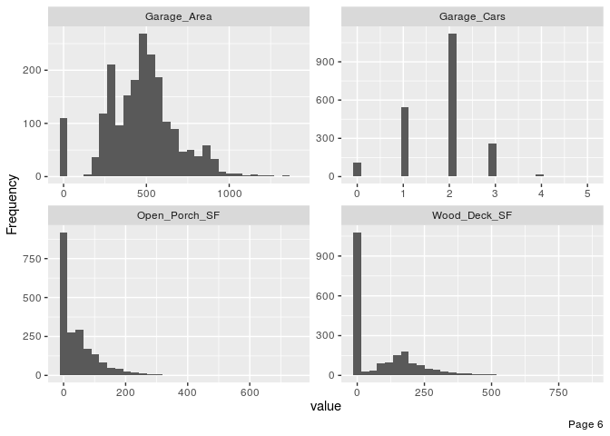

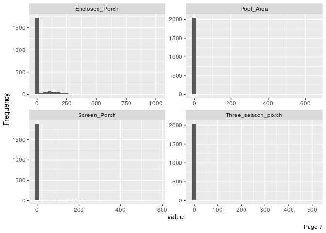

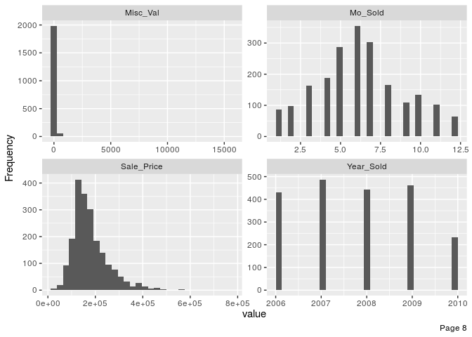

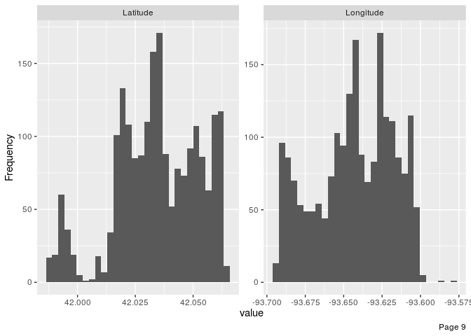

```r
plot_histogram(ames_train, ncol = 2L, nrow = 2L)
```

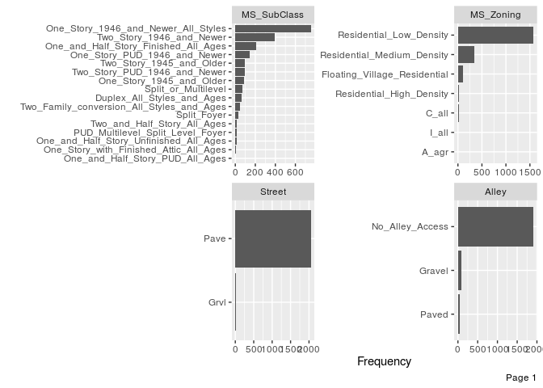

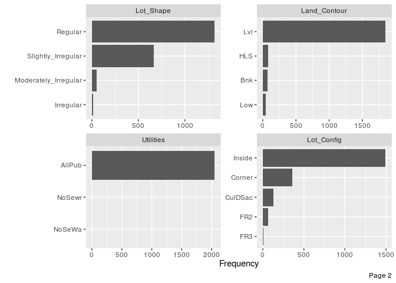

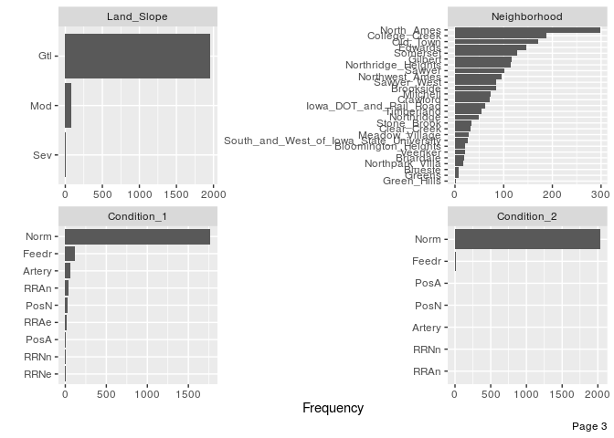

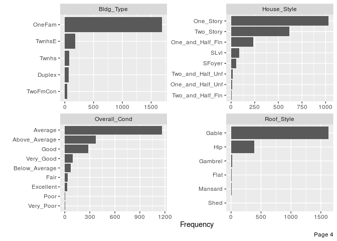

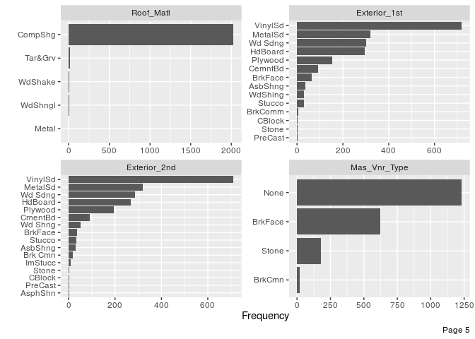

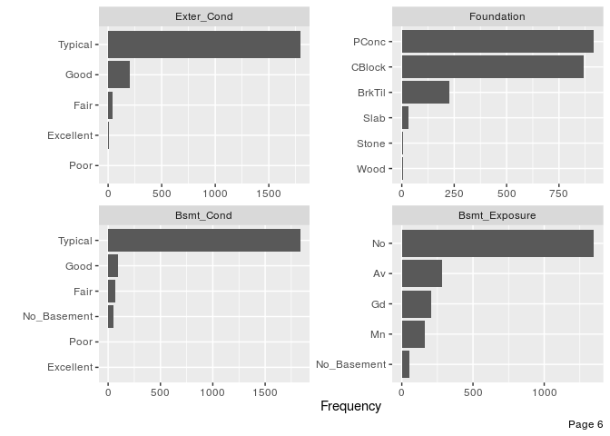

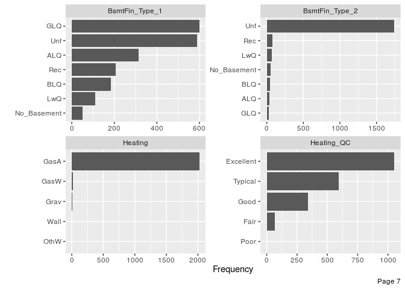

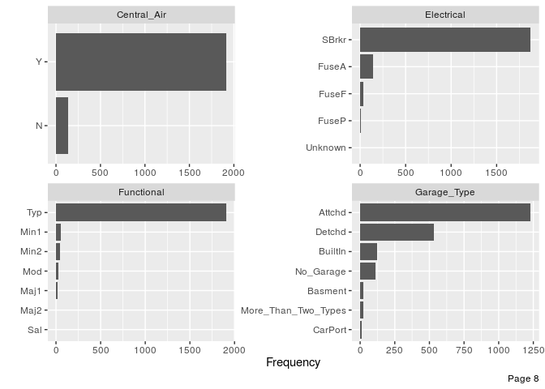

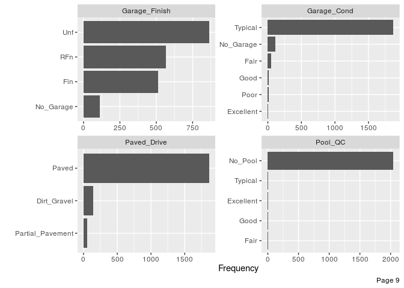

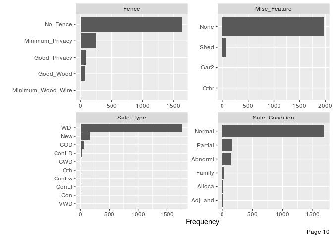

```r
plot_bar(ames_train, ncol = 2L, nrow = 2L)
```

Berdasarkan hasil visualisasi diperoleh bahwa sebagian besar variabel numerik memiliki distribusi yang tidak simetris. Sedangkan pada variabel kategorikal diketahui bahwa terdapat beberapa variabel yang memiliki variasi rendah atau mendekati nol. Untuk mengetahui variabel dengan variabilitas mendekati nol atau nol, dapat menggunakan sintaks berikut:

```r
nzvar <- nearZeroVar(ames_train, saveMetrics = TRUE) %>%
  rownames_to_column() %>%
  filter(nzv)
nzvar
```

```
##               rowname  freqRatio percentUnique zeroVar  nzv
## 1              Street  292.28571    0.09741841   FALSE TRUE
## 2               Alley   20.52688    0.14612762   FALSE TRUE
## 3        Land_Contour   22.28916    0.19483682   FALSE TRUE
## 4           Utilities 1025.00000    0.14612762   FALSE TRUE
## 5          Land_Slope   22.76744    0.14612762   FALSE TRUE
## 6         Condition_2  203.10000    0.34096444   FALSE TRUE
## 7           Roof_Matl  126.50000    0.24354603   FALSE TRUE
## 8           Bsmt_Cond   19.93478    0.29225524   FALSE TRUE
## 9      BsmtFin_Type_2   21.50617    0.34096444   FALSE TRUE
## 10            Heating  101.05000    0.24354603   FALSE TRUE
## 11      Kitchen_AbvGr   23.68675    0.19483682   FALSE TRUE
## 12         Functional   38.18000    0.34096444   FALSE TRUE
## 13     Enclosed_Porch  100.94118    7.40379932   FALSE TRUE
## 14 Three_season_porch  674.66667    1.16902094   FALSE TRUE
## 15       Screen_Porch  234.87500    4.52995616   FALSE TRUE
## 16          Pool_Area 2045.00000    0.43838285   FALSE TRUE
## 17            Pool_QC  681.66667    0.24354603   FALSE TRUE
## 18       Misc_Feature   30.49231    0.19483682   FALSE TRUE
## 19           Misc_Val  165.33333    1.41256698   FALSE TRUE
```

Berikut adalah ringkasan data pada variabel yang tidak memiliki variasi yang mendekati nol.

```r
without_nzvar <- select(ames_train, !nzvar$rowname)
skim(without_nzvar)
```

| Name | without_nzvar |
| --- | --- |
| Number of rows | 2053 |
| Number of columns | 55 |
| _______________________ |  |
| Column type frequency: |  |
| factor | 27 |
| numeric | 28 |
| ________________________ |  |
| Group variables | None |

Data summary

**Variable type: factor**

| skim_variable | n_missing | complete_rate | ordered | n_unique | top_counts |
| --- | --- | --- | --- | --- | --- |
| MS_SubClass | 0 | 1 | FALSE | 16 | One: 753, Two: 395, One: 211, One: 145 |
| MS_Zoning | 0 | 1 | FALSE | 7 | Res: 1571, Res: 338, Flo: 102, Res: 19 |
| Lot_Shape | 0 | 1 | FALSE | 4 | Reg: 1321, Sli: 666, Mod: 54, Irr: 12 |
| Lot_Config | 0 | 1 | FALSE | 5 | Ins: 1494, Cor: 361, Cul: 127, FR2: 62 |
| Neighborhood | 0 | 1 | FALSE | 27 | Nor: 298, Col: 187, Old: 171, Edw: 146 |
| Condition_1 | 0 | 1 | FALSE | 9 | Nor: 1768, Fee: 120, Art: 63, RRA: 35 |
| Bldg_Type | 0 | 1 | FALSE | 5 | One: 1692, Twn: 178, Twn: 74, Dup: 66 |
| House_Style | 0 | 1 | FALSE | 8 | One: 1030, Two: 614, One: 233, SLv: 84 |
| Overall_Cond | 0 | 1 | FALSE | 9 | Ave: 1168, Abo: 370, Goo: 280, Ver: 95 |
| Roof_Style | 0 | 1 | FALSE | 6 | Gab: 1627, Hip: 387, Gam: 17, Fla: 14 |
| Exterior_1st | 0 | 1 | FALSE | 14 | Vin: 718, Met: 321, Wd : 301, HdB: 295 |
| Exterior_2nd | 0 | 1 | FALSE | 16 | Vin: 710, Met: 321, Wd : 287, HdB: 267 |
| Mas_Vnr_Type | 0 | 1 | FALSE | 4 | Non: 1231, Brk: 624, Sto: 179, Brk: 19 |
| Exter_Cond | 0 | 1 | FALSE | 5 | Typ: 1792, Goo: 204, Fai: 43, Exc: 11 |
| Foundation | 0 | 1 | FALSE | 6 | PCo: 916, CBl: 870, Brk: 226, Sla: 30 |
| Bsmt_Exposure | 0 | 1 | FALSE | 5 | No: 1348, Av: 284, Gd: 205, Mn: 163 |
| BsmtFin_Type_1 | 0 | 1 | FALSE | 7 | GLQ: 599, Unf: 588, ALQ: 313, Rec: 207 |
| Heating_QC | 0 | 1 | FALSE | 5 | Exc: 1052, Typ: 593, Goo: 340, Fai: 66 |
| Central_Air | 0 | 1 | FALSE | 2 | Y: 1916, N: 137 |
| Electrical | 0 | 1 | FALSE | 5 | SBr: 1873, Fus: 140, Fus: 32, Fus: 7 |
| Garage_Type | 0 | 1 | FALSE | 7 | Att: 1230, Det: 534, Bui: 124, No_: 109 |
| Garage_Finish | 0 | 1 | FALSE | 4 | Unf: 863, RFn: 567, Fin: 512, No_: 111 |
| Garage_Cond | 0 | 1 | FALSE | 6 | Typ: 1870, No_: 111, Fai: 48, Goo: 12 |
| Paved_Drive | 0 | 1 | FALSE | 3 | Pav: 1862, Dir: 140, Par: 51 |
| Fence | 0 | 1 | FALSE | 5 | No_: 1646, Min: 243, Goo: 80, Goo: 75 |
| Sale_Type | 0 | 1 | FALSE | 10 | WD : 1775, New: 159, COD: 65, Con: 22 |
| Sale_Condition | 0 | 1 | FALSE | 6 | Nor: 1692, Par: 164, Abn: 139, Fam: 36 |

**Variable type: numeric**

| skim_variable | n_missing | complete_rate | mean | sd | p0 | p25 | p50 | p75 | p100 | hist |
| --- | --- | --- | --- | --- | --- | --- | --- | --- | --- | --- |
| Lot_Frontage | 0 | 1 | 57.00 | 33.69 | 0.00 | 41.00 | 62.00 | 78.00 | 313.00 | ▇▇▁▁▁ |
| Lot_Area | 0 | 1 | 10121.14 | 8120.98 | 1300.00 | 7313.00 | 9375.00 | 11512.00 | 215245.00 | ▇▁▁▁▁ |
| Year_Built | 0 | 1 | 1971.07 | 30.52 | 1872.00 | 1952.00 | 1973.00 | 2000.00 | 2010.00 | ▁▂▃▆▇ |
| Year_Remod_Add | 0 | 1 | 1984.42 | 20.79 | 1950.00 | 1966.00 | 1993.00 | 2004.00 | 2010.00 | ▅▂▂▃▇ |
| Mas_Vnr_Area | 0 | 1 | 102.59 | 179.08 | 0.00 | 0.00 | 0.00 | 164.00 | 1600.00 | ▇▁▁▁▁ |
| BsmtFin_SF_1 | 0 | 1 | 4.16 | 2.24 | 1.00 | 3.00 | 3.00 | 7.00 | 7.00 | ▅▆▁▁▇ |
| BsmtFin_SF_2 | 0 | 1 | 52.20 | 172.62 | 0.00 | 0.00 | 0.00 | 0.00 | 1474.00 | ▇▁▁▁▁ |
| Bsmt_Unf_SF | 0 | 1 | 558.79 | 437.52 | 0.00 | 219.00 | 467.00 | 797.00 | 2336.00 | ▇▅▂▁▁ |
| Total_Bsmt_SF | 0 | 1 | 1050.67 | 425.77 | 0.00 | 784.00 | 992.00 | 1298.00 | 3206.00 | ▂▇▃▁▁ |
| First_Flr_SF | 0 | 1 | 1158.36 | 383.60 | 334.00 | 880.00 | 1083.00 | 1384.00 | 3820.00 | ▇▇▁▁▁ |
| Second_Flr_SF | 0 | 1 | 336.30 | 426.47 | 0.00 | 0.00 | 0.00 | 702.00 | 2065.00 | ▇▃▂▁▁ |
| Gr_Liv_Area | 0 | 1 | 1499.56 | 494.55 | 334.00 | 1136.00 | 1441.00 | 1743.00 | 4676.00 | ▅▇▂▁▁ |
| Bsmt_Full_Bath | 0 | 1 | 0.43 | 0.53 | 0.00 | 0.00 | 0.00 | 1.00 | 3.00 | ▇▆▁▁▁ |
| Bsmt_Half_Bath | 0 | 1 | 0.06 | 0.25 | 0.00 | 0.00 | 0.00 | 0.00 | 2.00 | ▇▁▁▁▁ |
| Full_Bath | 0 | 1 | 1.57 | 0.56 | 0.00 | 1.00 | 2.00 | 2.00 | 4.00 | ▁▇▇▁▁ |
| Half_Bath | 0 | 1 | 0.38 | 0.50 | 0.00 | 0.00 | 0.00 | 1.00 | 2.00 | ▇▁▅▁▁ |
| Bedroom_AbvGr | 0 | 1 | 2.84 | 0.83 | 0.00 | 2.00 | 3.00 | 3.00 | 8.00 | ▁▇▂▁▁ |
| TotRms_AbvGrd | 0 | 1 | 6.42 | 1.54 | 2.00 | 5.00 | 6.00 | 7.00 | 14.00 | ▁▇▆▁▁ |
| Fireplaces | 0 | 1 | 0.61 | 0.65 | 0.00 | 0.00 | 1.00 | 1.00 | 3.00 | ▇▇▁▁▁ |
| Garage_Cars | 0 | 1 | 1.77 | 0.77 | 0.00 | 1.00 | 2.00 | 2.00 | 5.00 | ▅▇▂▁▁ |
| Garage_Area | 0 | 1 | 474.14 | 215.76 | 0.00 | 325.00 | 480.00 | 576.00 | 1390.00 | ▂▇▃▁▁ |
| Wood_Deck_SF | 0 | 1 | 92.98 | 123.01 | 0.00 | 0.00 | 0.00 | 168.00 | 857.00 | ▇▂▁▁▁ |
| Open_Porch_SF | 0 | 1 | 47.42 | 68.23 | 0.00 | 0.00 | 26.00 | 70.00 | 742.00 | ▇▁▁▁▁ |
| Mo_Sold | 0 | 1 | 6.20 | 2.71 | 1.00 | 4.00 | 6.00 | 8.00 | 12.00 | ▅▆▇▃▃ |
| Year_Sold | 0 | 1 | 2007.79 | 1.31 | 2006.00 | 2007.00 | 2008.00 | 2009.00 | 2010.00 | ▇▇▇▇▃ |
| Sale_Price | 0 | 1 | 180996.28 | 80258.90 | 13100.00 | 129500.00 | 160000.00 | 213500.00 | 755000.00 | ▇▇▁▁▁ |
| Longitude | 0 | 1 | -93.64 | 0.03 | -93.69 | -93.66 | -93.64 | -93.62 | -93.58 | ▅▅▇▆▁ |
| Latitude | 0 | 1 | 42.03 | 0.02 | 41.99 | 42.02 | 42.03 | 42.05 | 42.06 | ▂▂▇▇▇ |

Berikut adalah tabulasi observasi pada masing-masing variabel yang memiliki jumlah kategori >= 10.

```r
# MS_SubClass
count(ames_train, MS_SubClass) %>% arrange(n)
```

```
## # A tibble: 16 x 2
##    MS_SubClass                                   n
##    <fct>                                     <int>
##  1 One_and_Half_Story_PUD_All_Ages               1
##  2 One_Story_with_Finished_Attic_All_Ages        5
##  3 One_and_Half_Story_Unfinished_All_Ages       11
##  4 PUD_Multilevel_Split_Level_Foyer             14
##  5 Two_and_Half_Story_All_Ages                  17
##  6 Split_Foyer                                  32
##  7 Two_Family_conversion_All_Styles_and_Ages    43
##  8 Duplex_All_Styles_and_Ages                   66
##  9 Split_or_Multilevel                          75
## 10 One_Story_1945_and_Older                     91
## 11 Two_Story_PUD_1946_and_Newer                 96
## 12 Two_Story_1945_and_Older                     98
## 13 One_Story_PUD_1946_and_Newer                145
## 14 One_and_Half_Story_Finished_All_Ages        211
## 15 Two_Story_1946_and_Newer                    395
## 16 One_Story_1946_and_Newer_All_Styles         753
```

```r
# Neighborhood
count(ames_train, Neighborhood) %>% arrange(n)
```

```
## # A tibble: 27 x 2
##    Neighborhood                                n
##    <fct>                                   <int>
##  1 Green_Hills                                 2
##  2 Greens                                      7
##  3 Blueste                                     8
##  4 Northpark_Villa                            17
##  5 Briardale                                  18
##  6 Veenker                                    20
##  7 Bloomington_Heights                        21
##  8 South_and_West_of_Iowa_State_University    27
##  9 Meadow_Village                             29
## 10 Clear_Creek                                31
## # … with 17 more rows
```

```r
# Neighborhood
count(ames_train, Exterior_1st) %>% arrange(n)
```

```
## # A tibble: 14 x 2
##    Exterior_1st     n
##    <fct>        <int>
##  1 PreCast          1
##  2 Stone            1
##  3 CBlock           2
##  4 BrkComm          5
##  5 Stucco          30
##  6 WdShing         31
##  7 AsbShng         37
##  8 BrkFace         65
##  9 CemntBd         92
## 10 Plywood        154
## 11 HdBoard        295
## 12 Wd Sdng        301
## 13 MetalSd        321
## 14 VinylSd        718
```

```r
# Exterior_2nd
count(ames_train, Exterior_2nd) %>% arrange(n)
```

```
## # A tibble: 16 x 2
##    Exterior_2nd     n
##    <fct>        <int>
##  1 AsphShn          1
##  2 PreCast          1
##  3 CBlock           2
##  4 Stone            2
##  5 ImStucc         10
##  6 Brk Cmn         17
##  7 AsbShng         31
##  8 Stucco          32
##  9 BrkFace         35
## 10 Wd Shng         50
## 11 CmentBd         92
## 12 Plywood        195
## 13 HdBoard        267
## 14 Wd Sdng        287
## 15 MetalSd        321
## 16 VinylSd        710
```

## Kovarian

Kovarian dapat dicek melalui visualisasi *heatmap* koefisien korelasi (numerik) atau menggunakan *boxplot* (kontinu vs kategorikal)

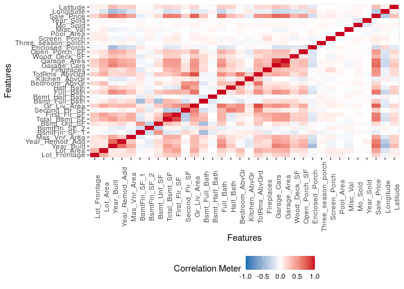

```r
plot_correlation(ames_train, type = "continuous",
                 cor_args = list(method = "spearman"))
```